# Mestrado em Hemoterapia: Bioestatística

## Intervalo de confiança para a média populacional

## Introdução

- Vimos que podemos utilizar uma estatística, como \(\bar{X}\), para estimar um parâmetro populacional, como a média populacional \(\mu\).
- Após coletarmos uma amostra aleatória calculamos \(\bar{x}\), que é a nossa estimativa para \(\mu\). Chamamos esta estimativa de **estimativa pontual**.
- Uma estimativa pontual fornece apenas um único valor plausível para o parâmetro. E sabemos que ela pode ser diferente para cada amostra obtida: distribuição amostral.
- O ideal é que se reporte não só a estimativa, mas também a sua imprecisão.
- Duas maneiras: fornecer a estimativa juntamente com o seu **erro-padrão** ou fornecer um intervalo de valores plausíveis para o parâmetro de interesse (**intervalo de confiança**).

## Introdução

Suponha que queremos estimar o parâmetro populacional \(\theta\) através de um intervalo.

Um intervalo de confiança (IC) para \(\theta\) é sempre da forma:

\[ \mbox{estimativa} \pm \mbox{margem de erro}\]

\[\hat \theta \pm \mbox{margem de erro}\]

Sendo:

- \(\hat \theta\) uma estimativa pontual de \(\theta\)
- **margem de erro:** quantidade que depende da distribuição amostral do estimador pontual de \(\theta\), do grau de confiança pré-estabelecido e do erro padrão da estimativa

## Distribuição da Média Amostral

A média amostral, \(\bar{X}_n\), tem em geral valores diferentes para diferentes amostras aleatórias obtidas: é uma variável aleatória.

Para obtermos a distribuição da média amostral:

- Coletar uma a.a. de tamanho \(n\) a partir da população com distribuição \(X\) e guardar o valor da média desta amostra.
- Coletar outra a.a. de tamanho \(n\) a partir da população com distribuição \(X\) e guardo o valor da média desta amostra. Repetir isso várias vezes.
- Construir um histograma com todas as médias obtidas para estudar o comportamento de \(\bar{X}_n\): avaliando a média, a dispersão e a distribuição.

## Teorema Central do Limite

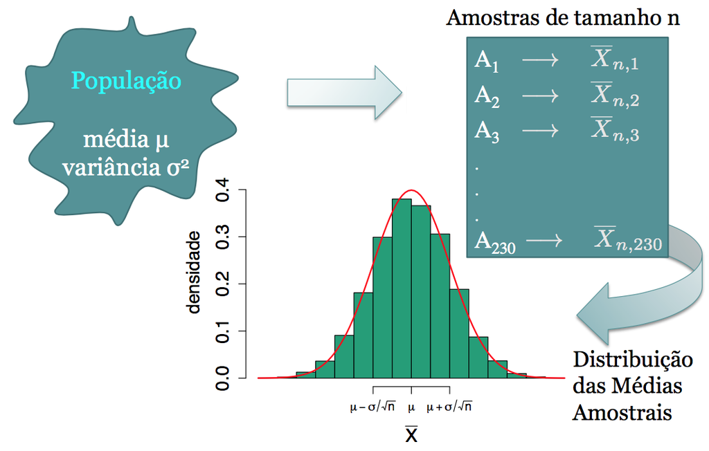

## Teorema Central do Limite

- Na prática: iremos coletar somente uma amostra de tamanho \(n\), não faremos inúmeras vezes esse processo. Teremos apenas 1 valor: \(\bar{x}\).
- Então como saberemos as propriedades deste estimador? Quão útil ele é?

> **Resultado (TCL):**

Para amostras aleatórias simples \(X_{1},...,X_{n}\) coletadas de uma população com média \(\mu\) e variância \(\sigma^{2}\), a distribuição amostral de \(\bar{X}_{n}\) aproxima-se de uma distribuição Normal de média \(\mu\) e variância \(\frac{\sigma^{2}}{n}\), quando \(n\) for suficientemente grande, isto é, \[ \bar{X}_{n} \sim N\left(\mu, \frac{\sigma^{2}}{n} \right)\]

## Teorema Central do Limite

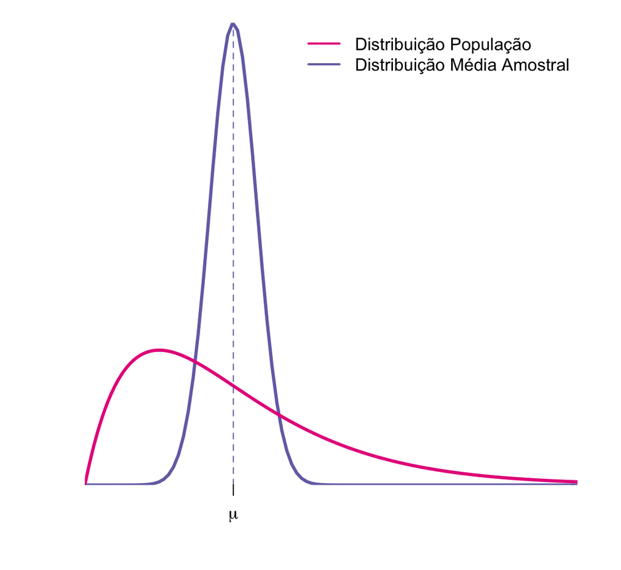

## Usando o TCL para construir um IC

- Temos uma amostra aleatoria \(X_1,\ldots,X_n\) e estamos usando a média amostral \(\bar{X}_n\) para estimar \(\mu\), a média populacional.
- Quão boa é esta estimativa? Ela tem boa precisão? Qual o grau de confiança?
- Em geral: queremos alto grau de confiança, por exemplo, \(1-\alpha=0.95\).
- Imagine que seja possível coletar uma amostra de tamanho \(n\) da população várias vezes. Para cada vez, você calcula \(\bar{x}\) é constrói um IC de 95% para \(\mu\). Imagine também que você conhece \(\mu\) e conte quantos dos intervalos contêm \(\mu\). A proporção de intervalos que contem \(\mu\) será próxima a 0.95.

## Interpretação do Intervalo de Confiança para \(\mu\)

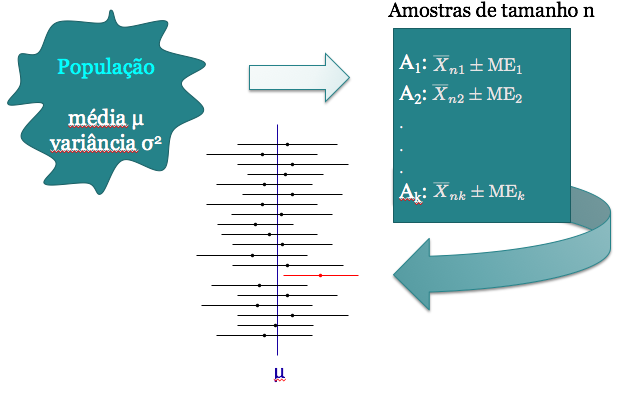

## Exemplo

Uma variável aleatória \(X\) tem distribução normal, com média 100 e desvio padrão 10.

Uma amostra de tamanho 16 a partir de \(X\) é realizada e calcula-se a média.

Represente, num único gráfico, as distribuições de \(X\) e \(\bar{X}\).

## Exemplo

Distribuições de \(X\) e \(\bar{X}\):

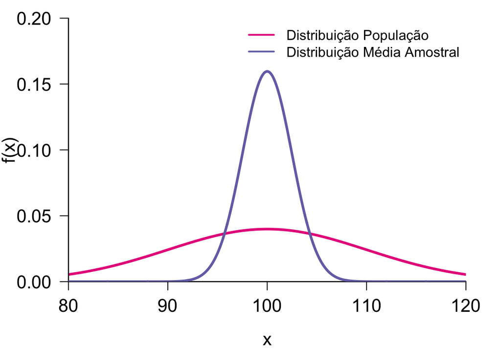

## Intervalo de Confiança para \(\mu\)

- Coletamos uma amostra aleatória \(X_1,X_2,\ldots,X_n\) de uma população com média \(\mu\) e a variância \(\sigma^2\) e usamos \(\bar{X}_n\) para estimar \(\mu\).
- Pelo TCL: \[\bar{X}_n \sim N(\mu,\sigma^2/n)\]
- Propriedade da Normal: \[Z=\frac{\bar{X}_n-\mu}{\sqrt{\sigma^2/n}} \sim N(0,1)\]

\[P(-z_{\alpha/2}<Z<z_{\alpha/2})=1-\alpha\]

## Intervalo de Confiança para \(\mu\): \(\sigma\) conhecido

Seja \(X_1,\ldots, X_n\) uma a.a. de uma população com média \(\mu\) e variância \(\sigma^2\) conhecida.

Um Intervalo de \(100(1-\alpha)\%\) de confiança para \(\mu\) é dado por: \[IC(\mu, 1-\alpha) = \left[ \bar{x} - z_{\alpha/2} \frac{\sigma}{\sqrt{n}}\,;\,\bar{x} +z_{\alpha/2}\frac{\sigma}{\sqrt{n}}\right]\]

## Exemplo: Café

Uma máquina enche pacotes de café com variância igual a 100\(g^2\). Ela estava regulada para encher os pacotes com uma média de 500g. Mas o fabricante desconfia que a máquina está desregulada e quer então estimar a nova média \(\mu\).

Uma amostra de 25 pacotes apresentou uma média de 485g. Encontre um \(IC\) de \(95\%\) para a verdadeira média \(\mu\).

\(\bar x = 485, n=25, \sigma=10, \alpha=0.05, z_{0.025}=1.96\)

\[ \begin{aligned} IC(\mu, 0.95) &= \left[ \bar{x} - z_{0.025} \frac{\sigma}{\sqrt{n}};\,\bar{x} +z_{0.025}\frac{\sigma}{\sqrt{n}}\right] \\ &= \left[485 - 1.96 \frac{10}{5}; 485 + 1.96 \frac{10}{5} \right] \\ &=[481.08; 488.92] \end{aligned} \]

## Tamanho da Amostra

**Exemplo:** Por experiência, sabe-se que o peso de um salmão de certo criatório segue uma distribuição normal com uma média que varia a cada estação, mas com desvio padrão sempre igual a 0.3 libras.

Se quisermos estimar o peso médio dos peixes de maneira que nossa estimativa seja diferente da verdadeira média em no máximo 0.1 libras para mais ou para menos com probabilidade igual a 0.9, qual o tamanho amostral necessário?

**Solução** \[IC(\mu, 1-\alpha) = \left[ \bar{x} -z_{\alpha/2}\frac{\sigma}{\sqrt{n}}\,;\, \bar{x} +z_{\alpha/2}\frac{\sigma}{\sqrt{n}}\right]\]

Margem de erro: \(z_{\alpha/2}\frac{\sigma}{\sqrt{n}}\)

## Tamanho da Amostra

Margem de erro 0.1, isto é, \[z_{\alpha/2}\frac{\sigma}{\sqrt{n}}=0.1\]

\(\alpha=0.1\) (90% de confiança) e \(z_{0.05}=1.645\).

\[1.645\frac{0.3}{\sqrt{n}}=0.1 \quad \Rightarrow \quad n=24.35\]

Tamanho amostral: 25

Em geral, para uma margem de erro \(m\) e confiança \(100(1-\alpha)\%\):

\[n=\left( \frac{z_{\alpha/2}}{m}\right)^2\sigma^2\]

## Intervalo de Confiança para \(\mu\): \(\sigma\) desconhecido

Seja \(X_1, \ldots, X_n\) uma a.a. de uma população com média \(\mu\), mas com variância \(\sigma^2\) desconhecida

Nesse caso, usaremos a variância amostral (\(s^2\)) como uma estimativa de \(\sigma^2\): \[s^2=\frac{1}{n-1}\sum_{i=1}^n(x_i-\bar{x})^2\]

Como consequência, não temos mais distribuição Normal, mas sim a **distribuição \(t\)-student** com \(n-1\) graus de liberdade:

\[T=\frac{\bar{X}_n-\mu}{\sqrt{s^2/n}}\sim t_{n-1}\]

\[P(-t_{n-1,\alpha/2}<T<t_{n-1,\alpha/2})=1-\alpha\]

Um intervalo de \(100(1-\alpha)\%\) de confiança para \(\mu\) é dado por: \[IC(\mu, 1-\alpha) = \left[ \bar{x} -t_{n-1,\alpha/2}\frac{s}{\sqrt{n}};\, \bar{x} +t_{n-1,\alpha/2}\frac{s}{\sqrt{n}}\right]\]

## Distribuição \(t\)-student e Normal Padrão

Para \(n\) grande a distribuição \(t\)-student se aproxima da normal padrão \(N(0,1)\).

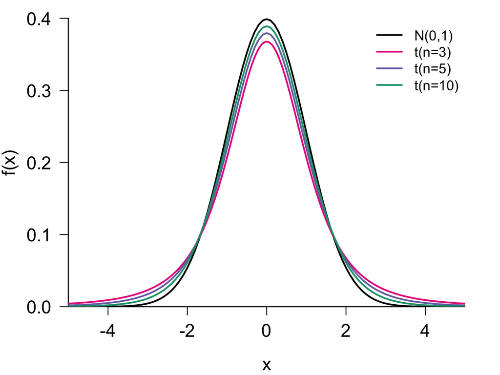

## Exemplo: Café

No exemplo da máquina que enche pacotes de café, suponha agora que a variância é **desconhecida**.

Lembre-se que uma amostra de \(25\) pacotes apresentou uma média de 485g. Observou-se um desvio padrão na amostra de 7.1g

Encontre um IC de 95% para a verdadeira média \(\mu\)

\[ \begin{aligned} IC(\mu, 0.95) &= \left[ \bar{x} - t_{24, 0.025} \frac{s}{\sqrt{n}};\,\bar{x} +t_{24, 0.025}\frac{s}{\sqrt{n}}\right] \\ &= \left [485 - 2.06 \frac{7.1}{5}; 485 + 2.06 \frac{7.1}{5} \right] \\ &=[482.07; 487.93] \end{aligned} \]

## Exemplo: Quantas horas de TV você assiste por dia?

O histograma a seguir apresenta a distribuição do número de horas de TV por dia entre os participantes de um estudo em que se coletou uma amostra aleatória.

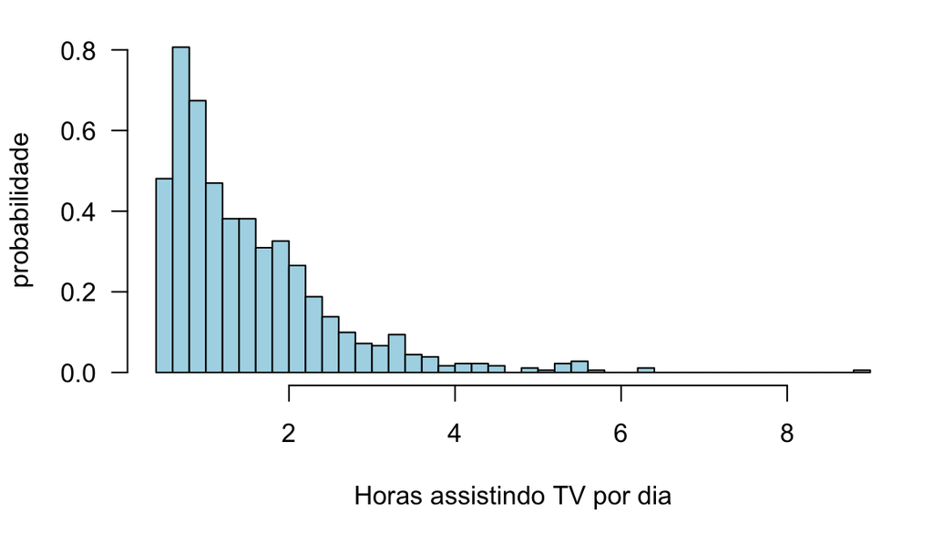

## Exemplo: horas de TV por dia

Encontre um IC de \(95\%\) para a média de horas que uma pessoa assiste por dia.

- \(n=905\) pessoas responderam.
- \(x_i\) é o número de horas de TV que a pessoa \(i\) da amostra assiste.
- \(\bar{x}=1.52\) e \(s=1\)
- Erro padrão da média amostral: \(s/\sqrt{n}=0.03\)

## Exemplo: horas de TV por dia

Utilizamos a distribuição Normal e não a distribuição t, pois \(n\) é grande.

- Pelo TCL: \(\bar{X}_n \sim N(\mu,\sigma^2/n)\)
- O IC 95% para \(\mu\) fica:

\[IC(\mu, 0.95) = \left[\bar{x}-1.96 \frac{s}{\sqrt{n}};\,\bar{x}+1.96\frac{s}{\sqrt{n}} \right]= [1.46\,;\,1.58]\]

Com grau de confiança igual a 95%, estimamos que a média populacional de horas de TV está entre 1.46 e 1.58 horas.

## Exemplo - Leite materno

O Ministério da Saúde está preocupado com quantidade de um certo componente tóxico no leite materno.

Em uma amostra de 20 mulheres, a quantidade do componente para cada uma foi:

```
## 16 0 0 2 3 6 8 2 5 0 12 10 5 7 2 3 8 17 9 1
```

Obtenha um intervalo de confiança de 95% para a quantidade média do componente no leite materno para a população.

## Exemplo - Solução

\(\bar{x}=5.8\)

\(s=5.08\)

\(n=20\)

\(t_{19,0.025}= 2.093\)

\[IC(\mu, 0.95) = \left[ \bar{x} -t_{n-1,\alpha/2}\frac{s}{\sqrt{n}}\,;\, \bar{x} +t_{n-1,\alpha/2}\frac{s}{\sqrt{n}}\right]\]

\[=\left[3.41,;\, 8.19\right]\]

Com grau de confiança igual a 95%, estimamos que a média da quantidade do componente entre as mulheres está entre 3.41 e 8.19.

## Exemplo: precisão e tamanho amostral

Qual deve ser o tamanho de uma amostra cuja população da qual ela será sorteada possui um desvio-padrão igual a 10, para que a diferença da média amostral para a média da população, em valor absoluto, seja menor que 1, com coeficiente de confiança igual a 95%.

## Exemplo: precisão e tamanho amostral

Pelo TCL: \(\bar{X}_n \sim N(\mu, 10^2/n)\)

Queremos \(P(|\bar{X}-\mu|<1) = 0.95\)

\[P(-1<\bar{X}-\mu<1) = 0.95\]

\[P\left(-\frac{1}{10/\sqrt{n}}<\frac{\bar{X}-\mu}{10/\sqrt{n}}<\frac{1}{10/\sqrt{n}}\right) = 0.95\]

O que é equivalente a \[P \left( -\sqrt{n}/10 < Z < \sqrt{n}/10 \right)=0.95\]

Como \(P(-1.96 < Z < 1.96) = 0.95\), então \[\frac{\sqrt{n}}{10} = 1.96 \quad \Rightarrow \quad n \approx 385\]

## Exemplo: precisão e tamanho amostral

Em geral, como já dissemos anteriormente, para uma margem de erro \(m\): \[n=\left(\frac{z_{\alpha/2}}{m}\right)^2 \sigma^2\]

## Leituras

[figure not shown]

- [Ross](http://www.sciencedirect.com/science/article/pii/B9780123743886000089): capítulo 8.
- [OpenIntro](https://www.openintro.org/stat/textbook.php): seção 4.2.

Slides produzidos pelos professores:

- Samara Kiihl
- Tatiana Benaglia
- Benilton Carvalho
- Rafael Maia